# Part II - ( prosper_loan_presentation)

## by FIDELIS WAWERU

## Investigation Overview

> I'll look at how Loan Original Amount, Income Range, Monthly stated income, Loan Status,Monthly stated income, monthly loan payment,Employment Status affect each other in my investigation. These variables are the main points of focus in this study.

## Dataset Overview

> This data set contains 113,937 loans with 81 variables on each loan, including loan amount, borrower rate (or interest rate), current loan status, borrower income, and many others. Please find the data dictionary in the link below [data dictionary](https://docs.google.com/spreadsheets/d/1gDyi_L4UvIrLTEC6Wri5nbaMmkGmLQBk-Yx3z0XDEtI/edit#gid=0)

### Distribution of LoanStatus

More than 50,000 borrowers have their loans as current, more than 30,000 have their loans completed and approximately less than a 1,000 have them as due and cancelled.

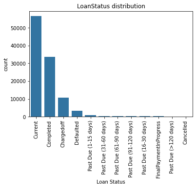

### Distribution of ListingCategory

The main objecjective of this plot is to find the reason for borrowers to take the loans. It is therefore observed that debt consolidation was the main reason as indicated but a count of above 50,000. However, there were other reasons such as homeimprovement, business, personal loan etc which had a relative low count of less than 10,000. From the distribution, Rv was the least reason as it appears to the far right side of the graph.

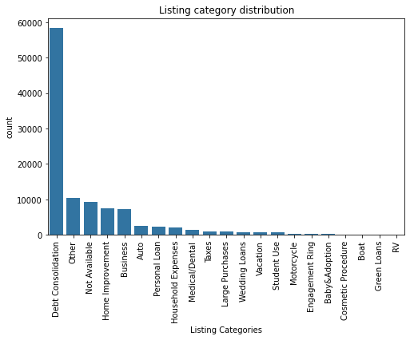

### Term, LoanStatus and BorrowerAPR

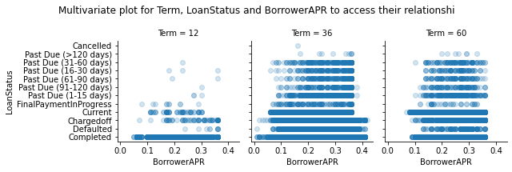

### Loan Original Amount and Income Range

Each violin shows the median,lower and upper quartile of the LoanOriginalAmount in every IncomeRange category. The 100,000+ have a greater interquartile range meaning that most borrowers under this category took a wide range of loan original amount.

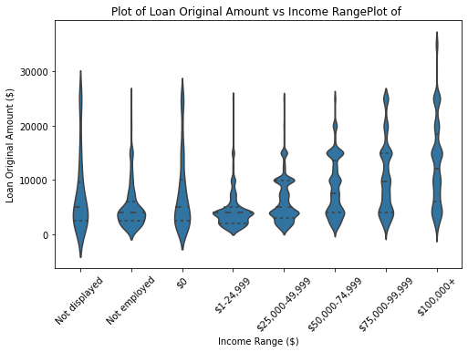

#### MonthlyLoanPayment,LoanOriginalAmount and term

60 months is quit a long time, but form the illustration below, we can say that most borrowers under this Loan term category made the least monthly payments for the loans as compared to those on 12 month term which is relatively high. We can also deduce that most borrowers acquired loans ranging form 0 to 25,000

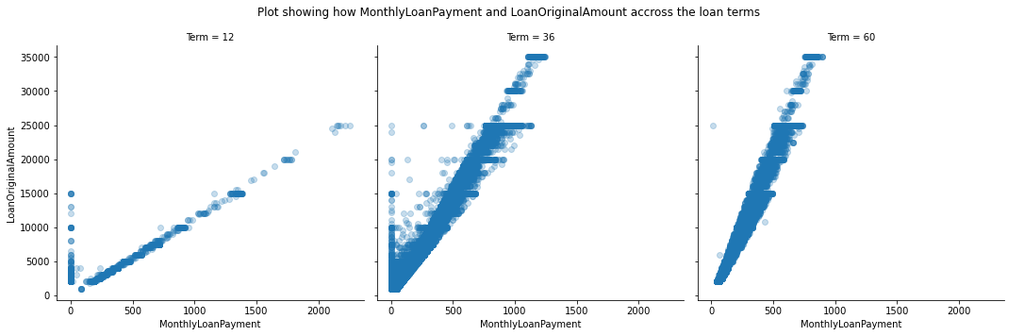

### LoanStatus and StatedMonthlyIncome

The bar graph below illustrates the relationship of `LoanStatus` to `StatedMonthlyIncome` and we can say that borrowers with the higher monthly income have their loan at the FinalPayment in progress. Those who have the least monthly income have their loans as cancelled due to various factors such as high interest rates which made it hard for them to pay the loans hence cancelling.

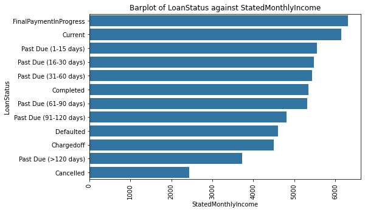

### MonthlyLoanPayment, LoanOriginalAmount and EmploymentStatus

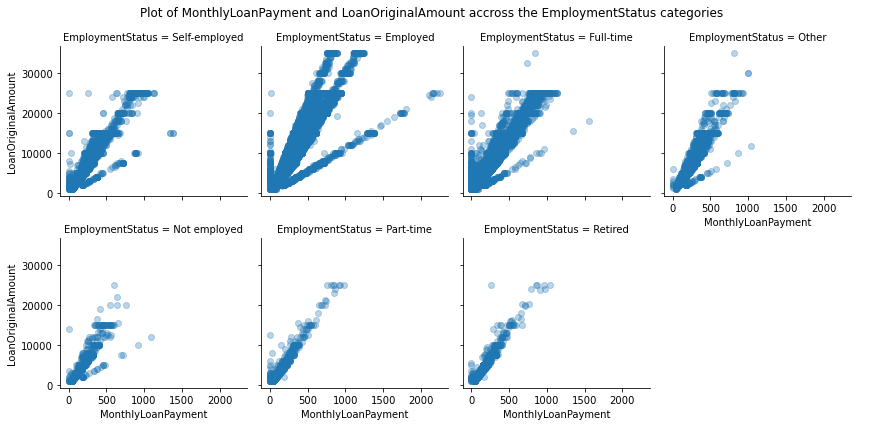